# pysseraactnotebook

## Lectura: The (Py)Tesseract Library

El reconocimiento óptico de caracteres, u **OCR**, es la **conversión de texto capturado en imágenes en texto utilizable por un ordenador.** En otras palabras, una herramienta OCR puede **leer el texto en imágenes.** El OCR es un **método común para procesar grandes volúmenes de texto impreso**, especialmente cuando ese texto **no está disponible en formato digital.** En aplicaciones prácticas, el OCR se ha utilizado para **escanear las páginas de los libros, reconocer las matrículas e incluso para convertir la escritura a mano en texto digitalizado.**

En este módulo del curso, vamos a usar un motor **OCR llamado Tesseract**. Tesseract fue desarrollado originalmente entre **1984 y 1994** como un proyecto de investigación de doctorado en **HP Labs**. El motor superó enormemente a los productos comerciales en ese momento, pero luego **se detuvo el desarrollo hasta que HP lanzó Tesseract como código abierto en 2005**. En **2006, Google comenzó a mantener la herramienta y desde entonces ha lanzado versiones actualizadas de Tesseract con soporte para más de 100 idiomas.** Creo que Tesseract es una gran herramienta, y un maravilloso ejemplo de cómo las empresas pueden participar en el desarrollo de software de código abierto. Así que antes de pasar mucho tiempo hablando de Tesseract, hablemos más sobre el software de código abierto.

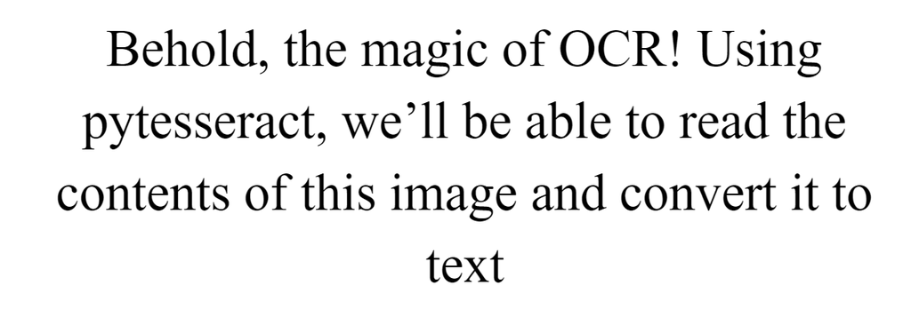

```python
# importamos y mostramos la imagen
from PIL import Image

image = Image.open("readonly/text.png")
display(image)
```

```python
# veamos algunas de las funciones que contiene
import pytesseract
dir(pytesseract)
```

```
['Output',
 'TesseractError',
 '__builtins__',
 '__cached__',
 '__doc__',
 '__file__',
 '__loader__',
 '__name__',
 '__package__',
 '__path__',
 '__spec__',
 'get_tesseract_version',
 'image_to_boxes',
 'image_to_data',
 'image_to_osd',
 'image_to_pdf_or_hocr',
 'image_to_string',
 'pytesseract']
```

```python
help(pytesseract.image_to_string)
```

```
Help on function image_to_string in module pytesseract.pytesseract:

image_to_string(image, lang=None, config='', nice=0, output_type='string')
    Returns the result of a Tesseract OCR run on the provided image to string
```

**Esta funcion toma como primer parametro una imagen**

```python
help(Image.Image.resize)
```

```
Help on function resize in module PIL.Image:

resize(self, size, resample=0, box=None)
    Returns a resized copy of this image.

    :param size: The requested size in pixels, as a 2-tuple:
       (width, height).
    :param resample: An optional resampling filter.  This can be
       one of :py:attr:`PIL.Image.NEAREST`, :py:attr:`PIL.Image.BOX`,
       :py:attr:`PIL.Image.BILINEAR`, :py:attr:`PIL.Image.HAMMING`,
       :py:attr:`PIL.Image.BICUBIC` or :py:attr:`PIL.Image.LANCZOS`.
       If omitted, or if the image has mode "1" or "P", it is
       set :py:attr:`PIL.Image.NEAREST`.
       See: :ref:`concept-filters`.
    :param box: An optional 4-tuple of floats giving the region
       of the source image which should be scaled.
       The values should be within (0, 0, width, height) rectangle.
       If omitted or None, the entire source is used.
    :returns: An :py:class:`~PIL.Image.Image` object.
```

Observe cómo la función PILLOW tiene un poco **más de información**. Primero está usando un formato específico llamado **reStructuredText**, que tiene una intención similar a las marcas de documentos como HTML, el lenguaje de La web. La intención es **incrustar la semántica en la propia documentación.** Por ejemplo, `en resize()` vemos las palabras **"tamaño de parámetro" con dos puntos alrededor.** Esto permite que los **motores de documentación que crean documentos web a partir del código fuente para vincular el parámetro a los documentos extendidos sobre ese parámetro.**

En este caso, los documentos extendidos nos dicen que el tamaño debe **pasarse como una tupla de ancho y alto.**Observe cómo los documentos de image_to_string, por ejemplo, indican que hay un parámetro "lang" que podemos use, pero luego no diga nada sobre para qué es ese parámetro o cuál es su formato.

Lo que esto realmente significa es que necesitamos profundizar más. Aquí hay un truco rápido si quieres ver el código fuente de una función: puede usar el comando inspeccionar getsource () e imprimir los resultados

```python
import inspect
src = inspect.getsource(pytesseract.image_to_string)
# imprimimos el codigo fuente de la funcion
print(src)
```

```
def image_to_string(image,
                    lang=None,
                    config='',
                    nice=0,
                    output_type=Output.STRING):
    '''
    Returns the result of a Tesseract OCR run on the provided image to string
    '''
    args = [image, 'txt', lang, config, nice]

    return {
        Output.BYTES: lambda: run_and_get_output(*(args + [True])),
        Output.DICT: lambda: {'text': run_and_get_output(*args)},
        Output.STRING: lambda: run_and_get_output(*args),
    }[output_type]()
```

En realidad, hay otra forma en jupyter, y es agregar *dos* signos de interrogación al final de una función o módulo determinado. Otros editores tienen características similares y es una gran razón para usar un entorno de desarrollo de software.

```python
pytesseract.image_to_string??
```

Podemos ver en el código fuente que realmente no hay mucha más información sobre cuáles son los parámetros son para esta función `image_to_string`. Esto se debe a que **debajo de la biblioteca pytesseract se llama a C ++ biblioteca que hace todo el trabajo duro, y el autor simplemente pasa por todas las llamadas al ejecutable tesseract subyacente.** Este es un problema común cuando se trabaja con bibliotecas de Python, y significa que **necesitamos hacer algo de investigación web para entender cómo podemos interactuar con tesseract.**

En un caso como este, busqué en Google "tesseract command line parameters" y el primer resultado fue : https://tesseract-ocr.github.io/tessdoc/Command-Line-Usage

Esto va a una página wiki que describe cómo llamar al ejecutable tesseract, y mientras leemos vemos que podemos hacer que tesseract use varios idiomas en su detección, como inglés e hindi, por pasándolos como "eng + hin". Muy genial.

```python
text = pytesseract.image_to_string(image)
print(text)
```

```
Behold, the magic of OCR! Using
pytesseract, we’ll be able to read the
contents of this image and convert it to
text
```

¡Se ve muy bien! Vemos que la salida incluye caracteres de nueva línea y representa fielmente el texto. Pero no incluye ningún formato especial. Sigamos y veamos algo con un poco más de matices.

## More Tesseract

En el ejemplo anterior, estábamos usando una imagen clara e inequívoca para la conversión. A veces habrá ruido en las imágenes que desea OCR, lo que dificulta la extracción del texto. Afortunadamente, hay técnicas que podemos utilizar para aumentar la eficacia de OCR con pytesseract y Pillow.

Usemos una imagen diferente esta vez, con el mismo texto que antes pero con ruido agregado en la imagen.

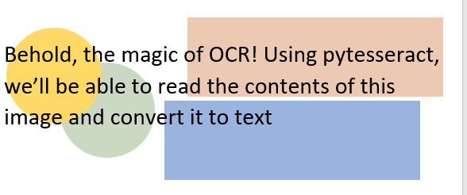

```python
from PIL import Image
img = Image.open("readonly/Noisy_OCR.PNG")
display(img)
```

Como puede ver, esta imagen tenía formas de diferentes opacidades detrás del texto, lo que puede confundir el motor tesseract. Veamos si el OCR funciona en esta imagen ruidosa

```python
import pytesseract
text = pytesseract.image_to_string(Image.open("readonly/Noisy_OCR.PNG"))
print(text)
```

```
e magic of OCR! Using pytesseract,
le to read the contents of this



d convert it to text
```

¡Esto es un poco sorprendente dado lo bien que funcionaba tesseract anteriormente! Experimentemos con la imagen utilizar técnicas que permitan un análisis de imágenes más eficaz. Primero, cambiemos el tamaño de la imagen

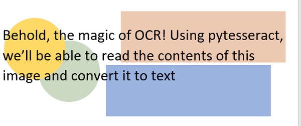

```
e magic of OCR! Using pytesseract,
le to read the contents of this
d convert it to text
```

```python
# First we will import PIL
import PIL
# Establecemos el ancho base de nuestra imagen
basewidth = 600
# Abrimos la imgen
img = Image.open("readonly/Noisy_OCR.PNG")
# Queremos obtener la relación de aspecto correcta, por lo que podemos hacerlo tomando el ancho de la base y dividiendo
#lo por el ancho real de la imagen
wpercent = (basewidth / float(img.size[0]))
# Con esa proporción, podemos obtener la altura adecuada de la imagen.
hsize = int((float(img.size[1]) * float(wpercent)))
# Finalmente, cambiemos el tamaño de la imagen. El antialiasing es una forma específica de cambiar el tamaño de las líneas para intentar hacerlas
# parece suave
img = img.resize((basewidth, hsize), PIL.Image.ANTIALIAS)
# guardamos el archivo
img.save('resized_nois.png')
# And finally, lets display it
display(img)
# and run OCR
text = pytesseract.image_to_string(Image.open('resized_nois.png'))
print(text)
```

```python
# hrm, no hay mejoras para cambiar el tamaño de la imagen. Convirtamos la imagen a escala de grises. Conversión de imágenes
# se puede hacer de muchas formas diferentes. Si buscamos en la documentación de PILLOW encontramos que uno de
# la forma más fácil de hacer esto es usar la función convert () y pasar la cadena 'L'
img = Image.open('readonly/Noisy_OCR.PNG')
img = img.convert('L') # convertimos  a escala de grises
# guardamos la imagen
img.save('greyscale_noise.jpg')
# corremos el ORC e imprimos el texto
text = pytesseract.image_to_string(Image.open('greyscale_noise.jpg'))
print(text)
```

```
Behold, the magic of OCR! Using pytesseract,
we'll be able to read the contents of this
image and convert it to text
```

# Aunque ahora tenemos el texto completo de la imagen, existen algunas otras técnicas que podríamos usar para ayudar a **mejorar la detección de OCR en caso de que los dos anteriores no ayuden.**

Este proceso **elimina el ruido en el proceso de OCR permitiendo una mayor precisión en el reconocimiento de imágenes.** Con Pillow, este proceso es sencillo. Vamos a abrir el impage ruidoso y convertirlo usando binarización

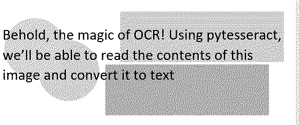

```python
img = Image.open('readonly/Noisy_OCR.PNG').convert('1')
# Now lets save and display that image
img.save('black_white_noise.jpg')
display(img)
```

Entonces, eso fue un poco mágico y realmente requirió una buena lectura de los documentos para descubrir que el número "1" es un parámetro de cadena para la función de conversión en realidad realiza la binarización.

Pero en realidad tiene todas las habilidades que necesita para escribir esta funcionalidad usted mismo. Veamos un ejemplo. Primero, definamos una función llamada **binarize, que toma en una imagen y un valor umbral**:

```python
def binarize(image_to_transform, threshold):
    # ahora, convierta esa imagen en una sola imagen en escala de grises usando convert ()
    output_image=image_to_transform.convert("L")
    # el valor de umbral generalmente se proporciona como un número entre 0 y 255, que
     # es el número de bits en un byte.
     # el algoritmo para la binarización es bastante simple, revise cada píxel en el
     # imagen y, si es mayor que el umbral, gírelo completamente hacia arriba (255), y
     # si está por debajo del umbral, bájelo completamente (0).
     # así que vamos a escribir esto en código. Primero, necesitamos iterar sobre todos los píxeles en el
     # imagen con la que queremos trabajar
    for x in range(output_image.width):
        for y in range(output_image.height):
            # para el píxel dado en w, h, verifiquemos su valor con el umbral
            if output_image.getpixel((x,y))< threshold: # tenga en cuenta que el primer parámetro es en realidad un objeto tupla
                # pongamos esto a cero
                output_image.putpixel( (x,y), 0 )
            else:
                # de lo contrario, establezcamos esto en 255
                output_image.putpixel( (x,y), 255 )

    return output_image
```

Probemos esta función en un rango de diferentes umbrales. Recuerda que puedes usar la función `range()` para generar una lista de números en diferentes tamaños de paso. `range()` se llama con un inicio, una parada y un tamaño de paso. Así que intentemos el rango (0, 257, 64), que debería generar 5imágenes de diferentes valores de umbral

```
Probar con umbral: 0
```

```
Probar con umbral: 64
```

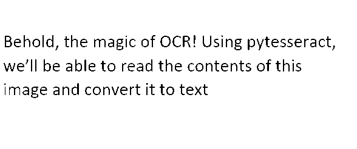

```
Behold, the magic of OCR! Using pytesseract,
we’ll be able to read the contents of this
image and convert it to text
Probar con umbral: 128
```

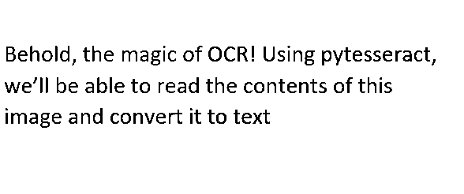

```
Behold, the magic of OCR! Using pytesseract,
we'll be able to read the contents of this
image and convert it to text
Probar con umbral: 192
```

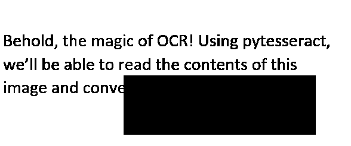

```
Behold, the magic of OCR! Using pytesseract,
we’ll be able to read the contents of this
image and conv
Probar con umbral: 256
```

```python
for thresh in range(0,257,64):
    print("Probar con umbral: " + str(thresh))
    # Permite mostrar la imagen binarizada en línea
    display(binarize(Image.open('readonly/Noisy_OCR.PNG'), thresh))
    # Y usemos tesseract en él. Es ineficaz binarizarlo dos veces, pero esto es solo para
     # una demostración
    print(pytesseract.image_to_string(binarize(Image.open('readonly/Noisy_OCR.PNG'), thresh)))
```

De esto podemos ver que un umbral de **0 esencialmente convierte todo en blanco**, que **el texto se vuelve más negrita a medida que avanzamos hacia un umbral más alto, y que las formas, que tienen un color gris relleno, se vuelven más evidentes a mayor umbrales.**

## Tesseract and Photographs

Probemos un nuevo ejemplo y juntemos algunas de las cosas que hemos aprendido. Aquí hay una imagen de un escaparate, carguemos e intentemos obtener el nombre del almacenar fuera de la imagen

[figure not shown]

```
''
```

```python
from PIL import Image
import pytesseract
image=Image.open('readonly/storefront.jpg')
display(image)
# Finalmente, intentemos ejecutar tesseract en esa imagen y veamos cuáles son los resultados
pytesseract.image_to_string(image)
```

Vemos en la parte inferior que solo hay una **cadena vacía.** Tesseract **no puede tomar esta imagen y saca el nombre.** Pero aprendimos a recortar las imágenes en el última serie de conferencias, así que intentemos ayudar a Tesseract recortando ciertas piezas.

Primero, configuremos el cuadro delimitador. En esta imagen, el nombre de la tienda está en una caja delimitado por $(315, 170, 700, 270)$

[figure not shown]

```
'FOSSIL'
```

```python
bounding_box=(315, 170, 700, 270)

# cortamos la imagen
title_image=image.crop(bounding_box)

# mostramos la iamgen y el texto reconocido
display(title_image)
pytesseract.image_to_string(title_image)
```

Genial, vemos cómo con un poco de reducción de problemas podemos hacer que eso funcione. Entonces ahora tenemos he podido tomar una imagen, preprocesarla donde esperamos ver el texto y convertir ese texto en una cadena que Python pueda entender.

Sin embargo, si vuelve a mirar la imagen, verá que **hay un pequeño letrero dentro del tienda que también tiene el nombre de la tienda.** Me pregunto si podemos reconocer el texto en ese letrero? Hagamos un intento.

Primero, **necesitamos determinar un cuadro delimitador para ese signo.**

```python
bounding_box=(900, 420, 940, 445)
little_sign=image.crop((900, 420, 940, 445))
display(little_sign)
```

¡Muy bien, eso es una pequeña señal! El OCR funciona mejor con imágenes de mayor resolución, por lo que **aumentemos el tamaño de esta imagen usando la función de cambio de tamaño de almohada ()**

Establezcamos el **ancho y la altura iguales a diez veces el tamaño que tiene ahora en una tupla (w, h).**

```python
new_size=(little_sign.width*10,little_sign.height*10)

help(little_sign.resize)
```

```
Help on method resize in module PIL.Image:

resize(size, resample=0, box=None) method of PIL.Image.Image instance
    Returns a resized copy of this image.

    :param size: The requested size in pixels, as a 2-tuple:
       (width, height).
    :param resample: An optional resampling filter.  This can be
       one of :py:attr:`PIL.Image.NEAREST`, :py:attr:`PIL.Image.BOX`,
       :py:attr:`PIL.Image.BILINEAR`, :py:attr:`PIL.Image.HAMMING`,
       :py:attr:`PIL.Image.BICUBIC` or :py:attr:`PIL.Image.LANCZOS`.
       If omitted, or if the image has mode "1" or "P", it is
       set :py:attr:`PIL.Image.NEAREST`.
       See: :ref:`concept-filters`.
    :param box: An optional 4-tuple of floats giving the region
       of the source image which should be scaled.
       The values should be within (0, 0, width, height) rectangle.
       If omitted or None, the entire source is used.
    :returns: An :py:class:`~PIL.Image.Image` object.
```

Podemos ver que hay varios filtros diferentes para cambiar el tamaño de la imagen.

```python
display(little_sign.resize( new_size, Image.NEAREST))
```

[output not shown]

```
0
```

```
4
```

```
2
```

[figure not shown]

```
5
```

[figure not shown]

```
3
```

[figure not shown]

```
1
```

[figure not shown]

```python
options=[Image.NEAREST, Image.BOX, Image.BILINEAR, Image.HAMMING, Image.BICUBIC, Image.LANCZOS]
for option in options:
    # imprima el nombre de la opción
    print(option)
    # vamos a mostrar cómo se ve esta opción en nuestro pequeño cartel
    display(little_sign.resize( new_size, option))
```

De esto podemos notar dos cosas. Primero, cuando imprimimos uno de los remuestreos valores **¡en realidad solo imprime un número entero!** Esto es muy común que el El desarrollador de **API escribe una propiedad, como Image.BICUBIC, y luego la asigna a un valor entero para pasarlo**.

Algunos lenguajes usan enumeraciones de valores, que es común en, digamos, Java, pero en Python esta es una forma bastante normal de hacer las cosas. Lo segundo que aprendimos es que hay varios **algoritmos diferentes para remuestreo de imágenes. En este caso, los filtros Image.LANCZOS e Image.BICUBIC hacen un buen trabajo.** Veamos si podemos reconocer el texto de esta imagen redimensionada

```python
# First lets resize to the larger size
bigger_sign=little_sign.resize(new_size, Image.BICUBIC)
# Lets print out the text
pytesseract.image_to_string(bigger_sign)
```

```
''
```

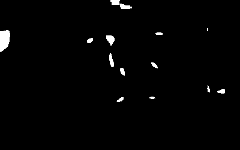

```
'Lae'
```

```python
# Bueno, no hay texto allí. Intentemos binarizar esto. Primero, déjame traer el
# código de binarización que hicimos antes
def binarize(image_to_transform, threshold):
    output_image=image_to_transform.convert("L")
    for x in range(output_image.width):
        for y in range(output_image.height):
            if output_image.getpixel((x,y))< threshold:
                output_image.putpixel( (x,y), 0 )
            else:
                output_image.putpixel( (x,y), 255 )
    return output_image

# Ahora, apliquemos binarizaciones con, digamos, un umbral de 190, e intentemos mostrar que
# así como también funciona el OCR
binarized_bigger_sign=binarize(bigger_sign, 190)
display(binarized_bigger_sign)
pytesseract.image_to_string(binarized_bigger_sign)
```

Ok, ese texto es bastante inútil. ¿Cómo deberíamos elegir la mejor binarización? ¿usar? Bueno, hay algunos métodos, pero intentemos algo muy simple para demuestrar qué tan bien puede funcionar esto. Tenemos una palabra en inglés que estamos tratando de detectar, "FOSSIL".

```python
eng_dict=[]
with open ("readonly/words_alpha.txt", "r") as f:
    data=f.read()
    # ahora queremos dividir esto en una lista basada en los caracteres de la nueva línea
    eng_dict=data.split("\n")

# Ahora recorramos todos los umbrales posibles y busquemos una palabra en inglés, imprimiendo
# sacarlo si existe
for i in range(150,170):
    # vamos a binarizar y convertir esto en valores de tring
    strng=pytesseract.image_to_string(binarize(bigger_sign,i))
    # Queremos eliminar los caracteres no alfabéticos, como ([% $]) del texto, aquí tienes
     # un método corto para hacer eso
     # primero, convierta nuestra cadena a minúsculas solamente
    strng=strng.lower()
    # luego vamos a importar el paquete de cadenas - tiene una buena lista de letras minúsculas
    import string
    # ahora vamos a iterar sobre nuestra cadena mirándola carácter por carácter, poniéndola en
     # el texto comaprison
    comparison=''
    for character in strng:
        if character in string.ascii_lowercase:
            comparison=comparison+character
    # finalmente, busquemos la comparación en el archivo del diccionario
    if comparison in eng_dict:

        print(comparison)
```

```
fossil
si
fossil
fossil
gas
gas
sl
sl
sil
```

Bueno, no perfecto, pero vemos fósil allí entre otros valores que están en el diccionario. Esta no es una mala forma de limpiar los datos de OCR. Puede resultar útil utilizar un idioma o dominio específico diccionario en la práctica, especialmente si está generando un motor de búsqueda para un lenguaje especializado como una base de conocimientos médicos o ubicaciones. Y si te desplazas hacia arriba y miras los datos con el que estábamos trabajando - esta pequeña pared que cuelga en el interior de la tienda - no es muy malo.

En este punto, ya ha aprendido a manipular imágenes y convertirlas en texto. En el el próximo módulo de este curso vamos a profundizar más en una biblioteca de visión por computadora que nos permite detectar rostros entre otras cosas. Luego, ¡al proyecto culminante!

## Jupyter Widgets (Optional)

En esta breve conferencia, quiero presentarles una de las funciones más avanzadas del Entorno de desarrollo de portátiles Jupyter llamado widgets. A veces quieres para interactuar con una función que ha creado y llamarla varias veces con diferentes parámetros.

Por ejemplo, si quisiéramos dibujar un cuadro rojo alrededor de una parte de un imagen para intentar ajustar la ubicación del recorte. Los widgets son una forma de hacer esto rápidamente en el navegador sin tener que aprender a escribir una gran aplicación de escritorio.

```python
from PIL import Image, ImageDraw

# Then we want to import the interact class from the widgets package
from ipywidgets import interact

# We will use interact to annotate a function. Lets bring in an image that we know we
# are interested in, like the storefront image from a previous lecture
image=Image.open('readonly/storefront.jpg')

# Ok, nuestra configuración está lista. Ahora usaremos el decorador interactivo para indicar
# que queremos envolver la función python. Hacemos esto usando el signo @. Esta voluntad
# tomar un conjunto de parámetros que sean idénticos a la función a llamar. Entonces Jupyter
# dibujará algunos controles deslizantes en la pantalla para permitirnos manipular estos valores. Decoradores,
# que es lo que describe el signo @, son declaraciones estándar de Python y solo un
# mano corta para funciones que envuelven otras funciones. Aunque son un poco avanzados,
# no hemos hablado de ellos en este curso, y es posible que deba tener algo de fe
@interact(left=100, top=100, right=200, bottom=200)

# Now we just write the function we had before
def draw_border(left, top, right, bottom):
    img=image.copy()
    drawing_object=ImageDraw.Draw(img)
    drawing_object.rectangle((left,top,right,bottom), fill = None, outline ='red')
    display(img)
```